# ChildcareEDA

Craig Entwistle

2023-06-21

# Thesis Ch1. Exploratory Data Analysis

Activating required packages.

```r
library(tidyverse)
library(ggplot2)
```

## Importing data and summary

Importing data from GitHub and providing top-level statistics.

This data is from Understanding Society (2009 - 2022) and has been merged together across waves for individual responses for a select related variables for childcare and labour market indicators.

```r
usoc = read_csv("https://raw.githubusercontent.com/Centwistle/phdch1/main/usoc_individuals.csv")
usoc %>% select(pidp, age_dv, sex_dv, ccare, jbhrs, jbft_dv) %>% summary(digits = 4)
```

```
##       pidp               age_dv           sex_dv           ccare
##  Min.   :2.244e+04   Min.   : -9.00   Min.   :-9.000   Min.   :-9.000
##  1st Qu.:4.081e+08   1st Qu.: 33.00   1st Qu.: 1.000   1st Qu.:-8.000
##  Median :7.484e+08   Median : 48.00   Median : 2.000   Median :-8.000
##  Mean   :7.801e+08   Mean   : 47.98   Mean   : 1.543   Mean   :-6.515
##  3rd Qu.:1.157e+09   3rd Qu.: 62.00   3rd Qu.: 2.000   3rd Qu.:-8.000
##  Max.   :1.653e+09   Max.   :104.00   Max.   : 2.000   Max.   : 2.000
##      jbhrs          jbft_dv
##  Min.   :-9.00   Min.   :-9.000
##  1st Qu.:-8.00   1st Qu.:-8.000
##  Median :-8.00   Median : 1.000
##  Mean   :11.56   Mean   :-3.101
##  3rd Qu.:37.00   3rd Qu.: 1.000
##  Max.   :97.90   Max.   : 2.000
```

Note to self: variable codings need tidying up for inapplicables / NAs etc. Also maybe find nicer table formatting

## Headline Trends in Childcare

First I look at rates of childcare utilisation across the whole of the UK for the time period covered (2009 - 2022). The code below filters out non-applicable variables (such as for where the year value was inapplicable), selects for parents only through those who answer positive **or** negative for whether they use childcare. Next it groups by year and calculates the average proportion (0 - 1) of parent responders who answered that they *did* use childcare in that given year. This is then piped into a line chart.

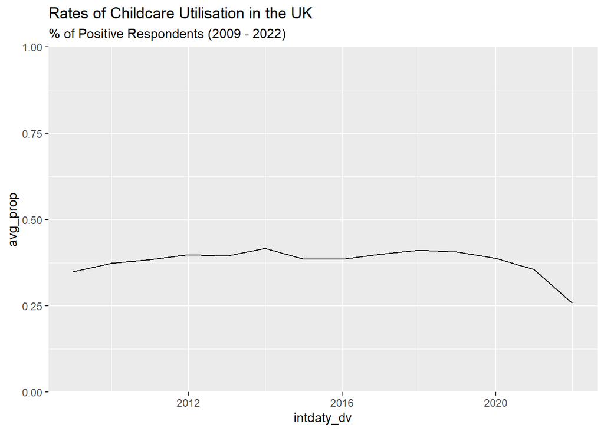

```r
usoc %>%
  filter(intdaty_dv > 0) %>%
  filter(ccare == 1 | ccare == 2) %>%
  group_by(intdaty_dv) %>%
  mutate(prop = 1 - (mean(ccare) - 1)) %>%
  summarise(avg_prop = mean(prop)) %>%
  ggplot(aes(x = intdaty_dv, y = avg_prop)) + geom_line() + scale_y_continuous(expand = c(0, 0), limits = c(0, 1)) +
  labs(title = "Rates of Childcare Utilisation in the UK", subtitle = "% of Positive Respondents (2009 - 2022)")
```

At first glance from the chart above, the trend of overall +% utilisation is flat over most of the time period until 2020 when it takes a significant downward swing downwards. However this is highly aggregated data and may be caused due to the data themselves. I investigate this next by disaggregating the UK into NUTS2 regions and repeat the above chart.

Initially, I look at the number of survey respondents within each year to check whether the underlying number of respondents is enought to draw any inferences from.

```r
usoc %>%
  filter(intdaty_dv > 0) %>%
  filter(ccare == 1 | ccare == 2) %>%
  group_by(intdaty_dv, Region) %>%
  mutate(prop = 1 - (mean(ccare) - 1)) %>%
  summarise(avg_prop = mean(prop), n = n_distinct(pidp))
```

```
## # A tibble: 68 × 4
## # Groups:   intdaty_dv [14]
##    intdaty_dv Region   avg_prop     n
##         <dbl> <chr>       <dbl> <int>
##  1       2009 England     0.351  3459
##  2       2009 NI          0.319   373
##  3       2009 Scotland    0.388   286
##  4       2009 Wales       0.309   178
##  5       2010 England     0.375  6973
##  6       2010 NI          0.339   606
##  7       2010 Scotland    0.430   743
##  8       2010 Wales       0.323   570
##  9       2010 <NA>        0.625     8
## 10       2011 England     0.388  6332
## # ℹ 58 more rows
```

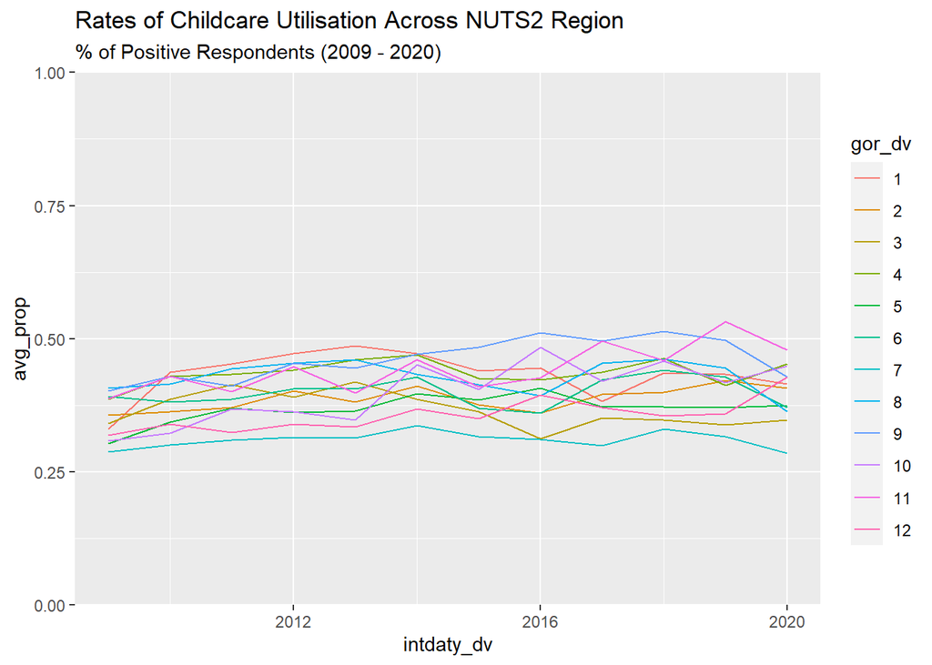

```r
usoc %>%
  filter(intdaty_dv > 0 & intdaty_dv < 2021) %>%
  filter(gor_dv >= 0) %>%
  filter(ccare == 1 | ccare == 2) %>%
  group_by(intdaty_dv, gor_dv) %>%
  mutate(prop = 1 - (mean(ccare) - 1)) %>%
  mutate(gor_dv = as.factor(gor_dv)) %>%
  summarise(avg_prop = mean(prop)) %>%
  ggplot(aes(x = intdaty_dv, y = avg_prop, group = gor_dv)) + geom_line(aes(color = gor_dv)) + scale_y_continuous(expand = c(0, 0), limits = c(0, 1)) +
  labs(title = "Rates of Childcare Utilisation Across NUTS2 Region", subtitle = "% of Positive Respondents (2009 - 2020)")
```

The above shows the same metric (proportion of parents answering positively to using childcare) over the same time period but disaggregated into the UK’s constitutent regions. Unsurprisingly there is variation within regions as to the overall proportion of users of childcare, again unsurprisingly with London (gor_dv - 7) being the lowest among all NUTS2 regions. Scotland has the highest proportion (gor_dv - 11).

To make differences slightly clearer - I aggregate English NUTS2 regions into one national variable, and compare against the other UK home regions below. Left hand chart shows just the observation lines, right hand chart layers over a linear trend line (both shown for clarity as trendlines obscure the individual observations somewhat).

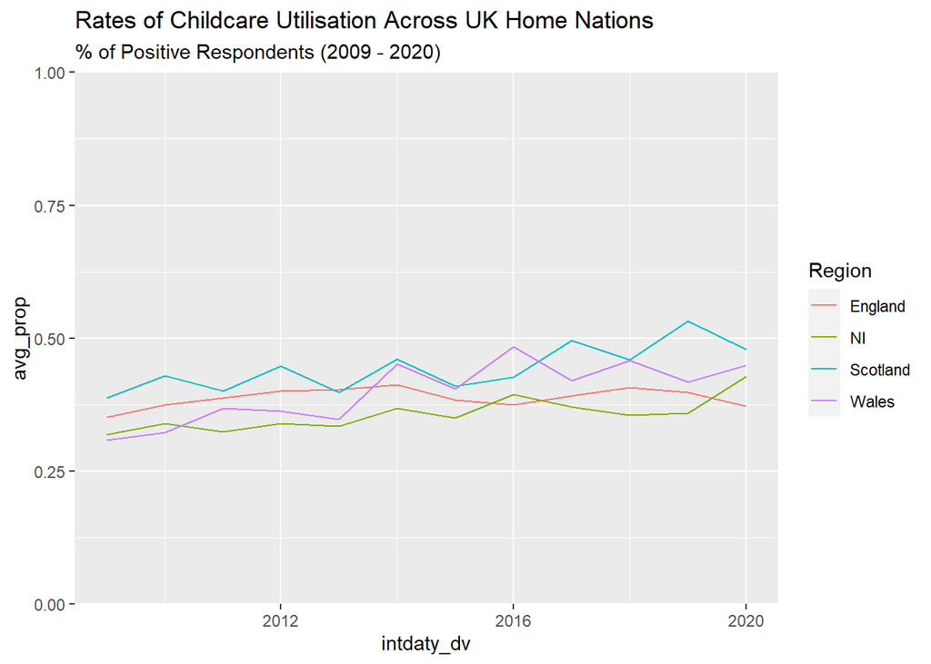

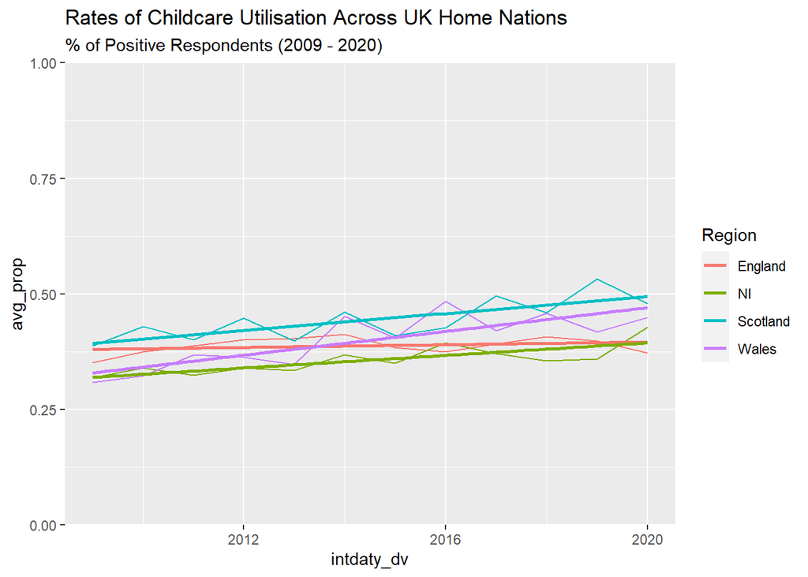

```r
usoc %>%
  filter(intdaty_dv > 0 & intdaty_dv < 2021) %>%
  filter(gor_dv >= 0) %>%
  filter(ccare == 1 | ccare == 2) %>%
  group_by(intdaty_dv, Region) %>%
  mutate(prop = 1 - (mean(ccare) - 1)) %>%
  summarise(avg_prop = mean(prop)) %>%
  ggplot(aes(x = intdaty_dv, y = avg_prop, group = Region)) + geom_line(aes(color = Region)) + scale_y_continuous(expand = c(0, 0), limits = c(0, 1)) +
  labs(title = "Rates of Childcare Utilisation Across UK Home Nations", subtitle = "% of Positive Respondents (2009 - 2020)")

usoc %>%
  filter(intdaty_dv > 0 & intdaty_dv < 2021) %>%
  filter(gor_dv >= 0) %>%
  filter(ccare == 1 | ccare == 2) %>%
  group_by(intdaty_dv, Region) %>%
  mutate(prop = 1 - (mean(ccare) - 1)) %>%
  summarise(avg_prop = mean(prop)) %>%
  ggplot(aes(x = intdaty_dv, y = avg_prop, group = Region)) + geom_line(aes(color = Region)) + scale_y_continuous(expand = c(0, 0), limits = c(0, 1)) +
  stat_smooth(method = "lm", formula = y ~ x, se = FALSE, aes(color = Region)) +
  labs(title = "Rates of Childcare Utilisation Across UK Home Nations", subtitle = "% of Positive Respondents (2009 - 2020)")
```

Here we observe both the heterogenous levels of childcare utilisation and the varying trends across the countries.

As in the NUTS2 level of disaggregation, Scotland both begins and ends the series with the highest proportion of respondents answering that they use childcare, while England begins as the second highest and then drops down to bottom by 2020. Wales and Northern Ireland both begin with relatively similar proportions in 2009 but end in 2020 having increased their values by quite some amount.

Turning to the right-hand chart, this more clearly shows the trend differences in proportions of positive respondents. Scotland, NI and particularly Wales demonstrate strong upward trends in childcare utilisation from 2009 to 2020. England bucks the trend with relatively flat line (very slightly upward sloping but muted compared to the others).

Note: large year-on-year volatility in proportion for Scotland, Wales and NI. This is not present for England, however the England variable was generated by taking an (non-weighted) average of all other English regions - so likely will have smoothed out volatility from those NUTS2 regions.

This needs further investigation. Checking simple correlation of year-wise and region-wise individual sample sizes did not yield any correlation between survey sample and volatility.

## Labour Market Characteristics and Childcare

First let us look simply at the difference in hours worked between men and women. Below is a distribution of hours worked within the Understanding Society dataset differentiated by sex. Vertical lines represent the average values. The table for average value is below.

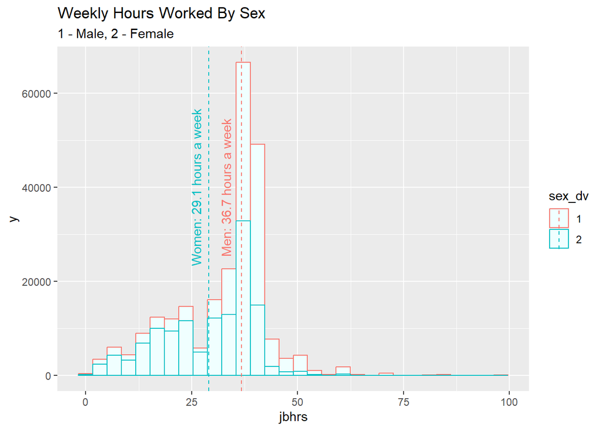

```r
usoc %>% filter(sex_dv > 0 & jbhrs >= 0) %>%
  mutate(sex_dv = as.factor(sex_dv)) %>%
  ggplot(aes(x = jbhrs, group = sex_dv, color = sex_dv)) + geom_histogram(fill = "azure") +
  geom_vline(aes(xintercept = mean(jbhrs[sex_dv == 1]), color = sex_dv[1]), linetype = "dashed") +
  geom_vline(aes(xintercept = mean(jbhrs[sex_dv == 2]), color = sex_dv), linetype = "dashed") +
  labs(title = "Weekly Hours Worked By Sex", subtitle = "1 - Male, 2 - Female") +
  annotate("text", x = 33, y = 40000, label = "Men: 36.7 hours a week", angle = 90, color = '#F8766D') +
  annotate("text", x = 26, y = 40000, label = "Women: 29.1 hours a week", angle = 90, color = '#00BFC4')
```

```r
usoc %>% filter(sex_dv > 0 & jbhrs >= 0) %>%
  mutate(sex_dv = as.factor(sex_dv)) %>%
  group_by(sex_dv) %>%
  summarise(avg_hrs = mean(jbhrs))
```

```
## # A tibble: 2 × 2
##   sex_dv avg_hrs
##   <fct>    <dbl>
## 1 1         36.7
## 2 2         29.1
```

Evidently, and unsurprisingly, there is a large difference in hours worked between men and women. Men typically work far more full-time hours (evidenced by the red values bunching around the 37.5 and 40 hour marks particularly the latter - while women are more densely concentrated in the spectrum of part-time work).

Now I turn to weekly hours worked within the data set - looking at data characteristics before turning to the interaction of hours worked in relation to the childcare variables.

Secondly I generate simple hours worked comparisons between both parents using childcare, parents not using childcare and non-parents who are in work of some kind.

```r
usoc %>%
  filter(intdaty_dv > 0 & intdaty_dv < 2021 & jbhrs > 0) %>%
  filter(ccare == 1 | ccare == 2 | ccare == -8) %>%
  group_by(ccare) %>%
  summarise(mean_hrs_worked = mean(jbhrs), median_hrs_worked = median(jbhrs))
```

```
## # A tibble: 3 × 3
##   ccare mean_hrs_worked median_hrs_worked
##   <dbl>           <dbl>             <dbl>
## 1    -8            33.6                37
## 2     1            27.7                28
## 3     2            26.4                26
```

In the above -8 corresponds to non-parents who work, 1 to parents using childcare of some kind and 2 to parents who do not use childcare.

As we can see, non-parents work on average around ~6-7 hours more per work than parents at 33.6 hrs/week. Parents utilising childcare work on average 27.7 hours per week, and non-childcare using parents work around 26.4 hours per week; meaning that childcare using parents work on average 1.2 hours *more* than non-childcare using parents.

Using median values to account for potential outliers (more below) - shows a slightly different picture. Non-parents work significantly more, approaching average full-time hours, while the gap for parents remains relatively similar. Childcare-using parents work 28 hours per week and non-using parents work 26 hours per week (2hr per week difference).

To visualise more clearly, I plot the above onto a histogram of hours worked below, with proportions of those hours worked differentiated between childcare using parents and not as well as the average values plotted in as a vertical line.

Note: Charting with non-parents included broke the chart for some reason, needs implementing.

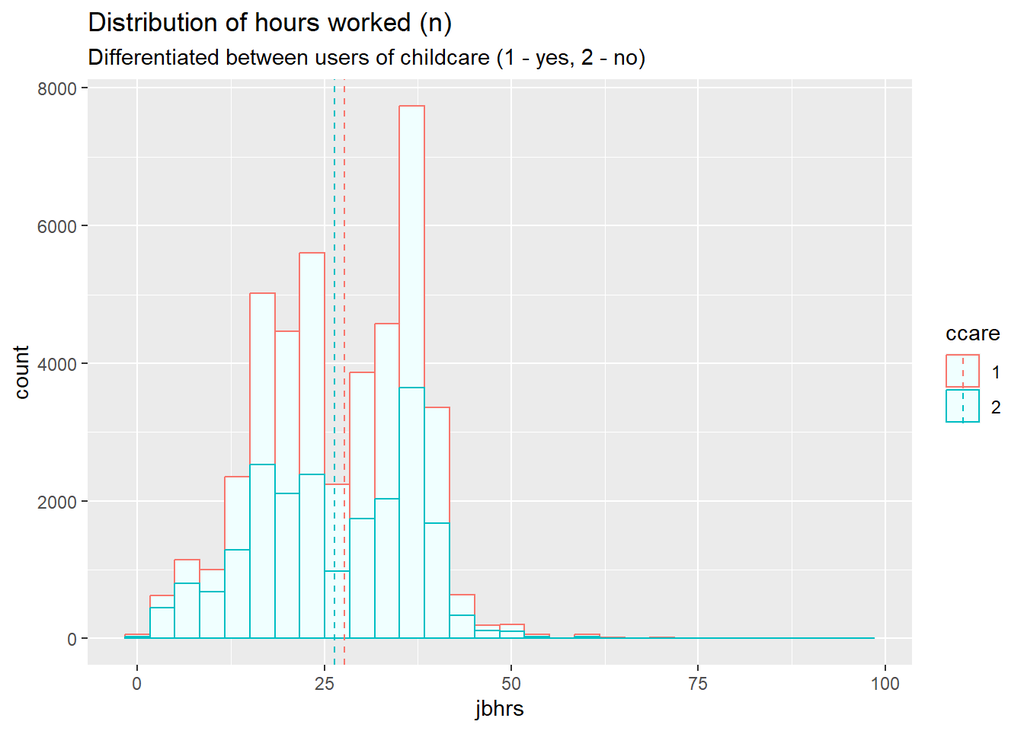

```r
usoc %>%
  filter(intdaty_dv > 0 & intdaty_dv < 2021) %>%
  filter(jbhrs > 0) %>%
  filter(ccare == 1 | ccare == 2) %>%
  mutate(ccare = as.factor(ccare)) %>%
  ggplot(aes(x = jbhrs, group = ccare, color = ccare)) + geom_histogram(fill = "azure") +
  geom_vline(aes(xintercept = mean(jbhrs[ccare == 1]), color = ccare[1]), linetype = "dashed") +
  geom_vline(aes(xintercept = mean(jbhrs[ccare == 2]), color = ccare), linetype = "dashed") +
  labs(title = "Distribution of hours worked (n)", subtitle = "Differentiated between users of childcare (1 - yes, 2 - no)")
```

The above shows the distribution of weekly hours worked for all respondents across waves, from 2009 to 2020. Unsurprisingly we see a bimodal distribution - with clumping of responses around the 20-25 hours worked per week area and at 40 hours worked per week, corresponding to part-time and full-time workers respectively.

The distribution is also relatively right-skewed due to small numbers of values expressed further along hours worked - to better get an idea of how these vary and the degree to which they are outliers (as they are not easily identified on the histogram) I plot a boxplot and a violin plot of hours worked differentiated by childcare below.

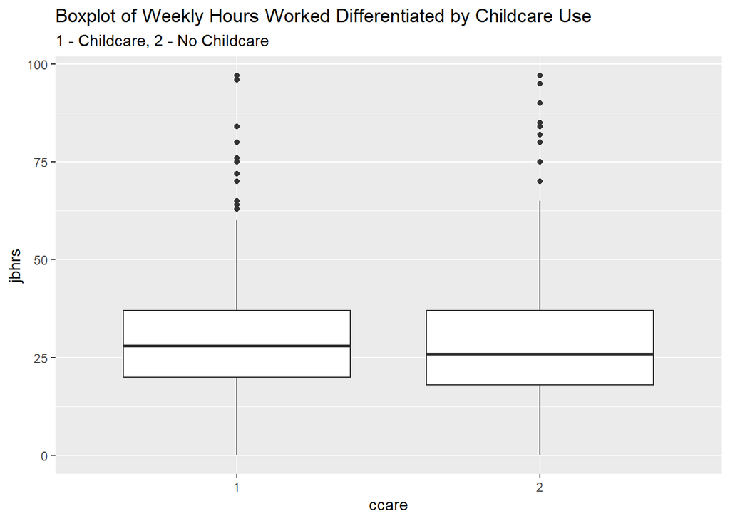

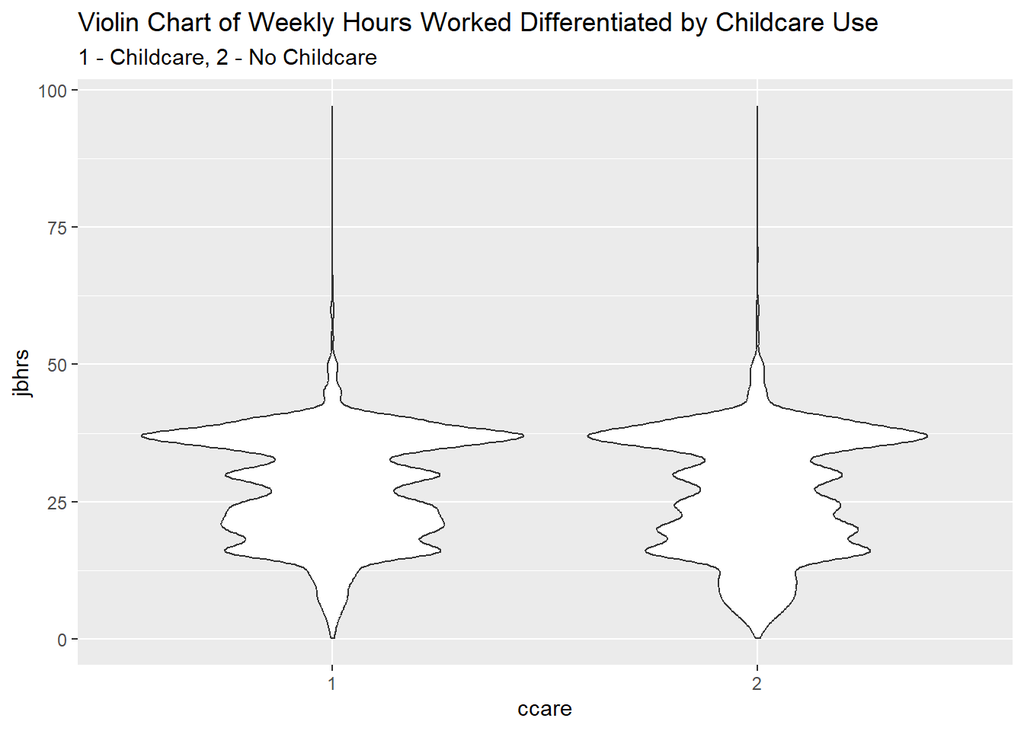

```r
usoc %>%
  filter(intdaty_dv > 0 & intdaty_dv < 2021) %>%
  filter(jbhrs > 0) %>%
  filter(ccare == 1 | ccare == 2) %>%
  mutate(ccare = as.factor(ccare)) %>%
  ggplot(aes(ccare, jbhrs, group = ccare)) + geom_boxplot() +
  labs(title = "Boxplot of Weekly Hours Worked Differentiated by Childcare Use", subtitle = "1 - Childcare, 2 - No Childcare")

usoc %>%
  filter(intdaty_dv > 0 & intdaty_dv < 2021) %>%
  filter(jbhrs > 0) %>%
  filter(ccare == 1 | ccare == 2) %>%
  mutate(ccare = as.factor(ccare)) %>%
  ggplot(aes(ccare, jbhrs, group = ccare)) + geom_violin() +
  labs(title = "Violin Chart of Weekly Hours Worked Differentiated by Childcare Use", subtitle = "1 - Childcare, 2 - No Childcare")
```

Given that the data exhibit bimodal distributionsm, I also add in a violin plot to better demonstrate the non-normal distribution. However, the boxplot clearly shows potential outliers. While there are a number of individuals who work very few hours, this appears normal - there are a number of observations approaching 100 hours worked per week. A quick scan of the data (below) shows how high some of the responses get.

```r
usoc %>%
  filter(intdaty_dv > 0 & intdaty_dv < 2021) %>%
  filter(jbhrs > 0) %>%
  filter(ccare == 1 | ccare == 2) %>%
  arrange(desc(jbhrs)) %>%
  select(pidp, intdaty_dv, age_dv, jbhrs) %>%
  head(10)
```

```
## # A tibble: 10 × 4
##          pidp intdaty_dv age_dv jbhrs
##         <dbl>      <dbl>  <dbl> <dbl>
##  1  952745291       2013     35    97
##  2  272128531       2014     43    97
##  3  476811247       2014     53    97
##  4  680625611       2015     31    96
##  5 1377768490       2016     36    95
##  6 1428979207       2012     52    90
##  7  272128531       2015     44    90
##  8  477995137       2018     47    90
##  9  819643449       2010     42    85
## 10 1088660971       2014     39    84
```

Some responses indicate 97 hours worked per week (19.4 hrs, 16.1 hrs and 14 hrs worked per day on a 5 day, 6 day and 7 day week respectively). This suggests that some of these responses may be outliers - although not enough information is present in this dataset to immediately rule them out.

It is feasible that some professions may actually work such long hours. Understanding Society does include what sector of work the individual is employed in (by SIC code), although it is not included within this slice of the data. For example, it is not inconceivable that someone working within finance may work those hours.

Next, I turn to the proportion of those working certain hours who use childcare or not to get an idea of whether the proportion of childcare using parents increases or decreases as hours work changed.

Note: for some reason this did not turn out to be possible using a histogram so this had to be jerry-rigged through a bar chart.

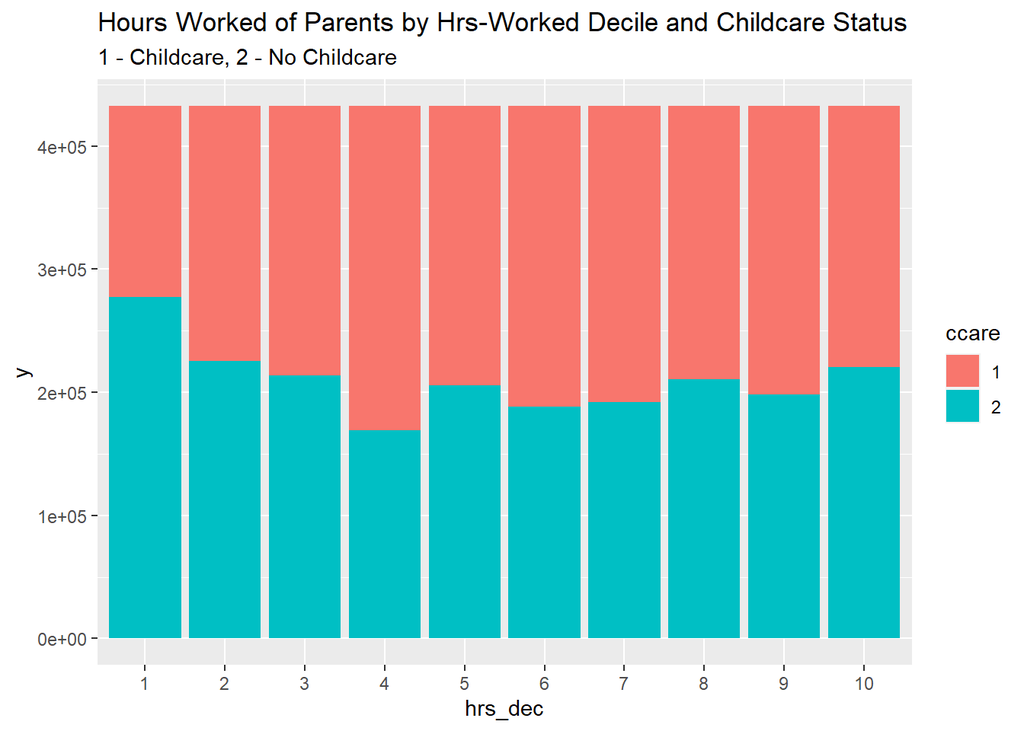

```r
 usoc %>%
  filter(intdaty_dv > 0 & intdaty_dv < 2021) %>%
  filter(jbhrs > 0) %>%
  filter(ccare == 1 | ccare == 2) %>%
  mutate(hrs_dec = ntile(jbhrs, 10), ccare = as.factor(ccare)) %>%
  mutate(hrs_dec = as.factor(hrs_dec)) %>%
  group_by(hrs_dec) %>%
  mutate(prop = 1 - (mean(ccare) - 1), n = n_distinct(pidp)) %>%
  ggplot(aes(x = hrs_dec, y = 100, fill = ccare)) + geom_col() +
  labs(title = "Hours Worked of Parents by Hrs-Worked Decile and Childcare Status", subtitle = "1 - Childcare, 2 - No Childcare")
```

Note: for the above to work, hours worked had to be transformed into a discrete variable. In this case, I opted for deciles - so each bar represents 10% of working parents by their hours worked ordered by hours worked. Y-axis represents the number of observations for each decile, and the fill represents the proportion of that decile using or not using childcare.

While not robust - it does suggest that childcare usage allows parents to work more hours.

Below I repeat the exercise but explicitly using the full-time and part-time variables in Understanding Society.

```r
usoc %>%
  filter(intdaty_dv > 0 & intdaty_dv < 2021) %>%
  filter(ccare == 1 | ccare == 2) %>%
  filter(jbft_dv == 1 | jbft_dv == 2 | jbft_dv == -8) %>%
  mutate(jbft_dv = as.factor(jbft_dv)) %>%
  group_by(jbft_dv) %>%
  mutate(prop = 1 - (mean(ccare) - 1), n = n_distinct(pidp)) %>%
  summarise(avg_prop = mean(prop))
```

```
## # A tibble: 3 × 2
##   jbft_dv avg_prop
##   <fct>      <dbl>
## 1 -8         0.175
## 2 1          0.520
## 3 2          0.481
```

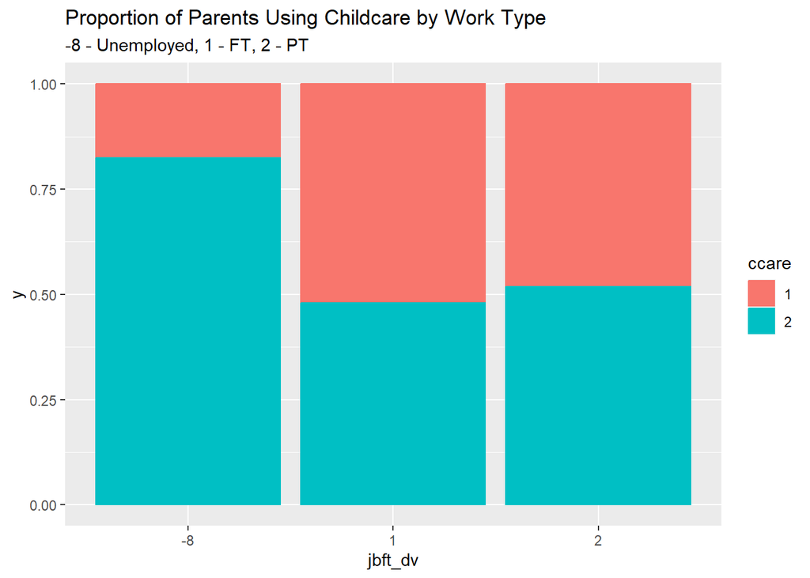

```r
usoc %>%
  filter(intdaty_dv > 0 & intdaty_dv < 2021) %>%
  filter(ccare == 1 | ccare == 2) %>%
  filter(jbft_dv == 1 | jbft_dv == 2 | jbft_dv == -8) %>%
  mutate(jbft_dv = as.factor(jbft_dv), ccare = as.factor(ccare)) %>%
  ggplot(aes(x = jbft_dv, y = 100, fill = ccare, color = ccare)) + geom_col(position = "fill") +
  labs(title = "Proportion of Parents Using Childcare by Work Type", subtitle = "-8 - Unemployed, 1 - FT, 2 - PT")
```

Referring back to the first chart in the notebook, it appears that the unemployed or non-working contribute significantly to the dragging down of childcare usage as a % overall for the UK.

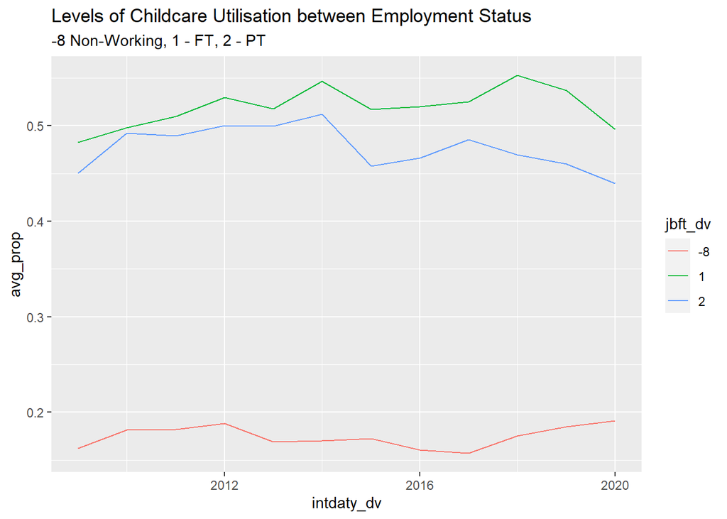

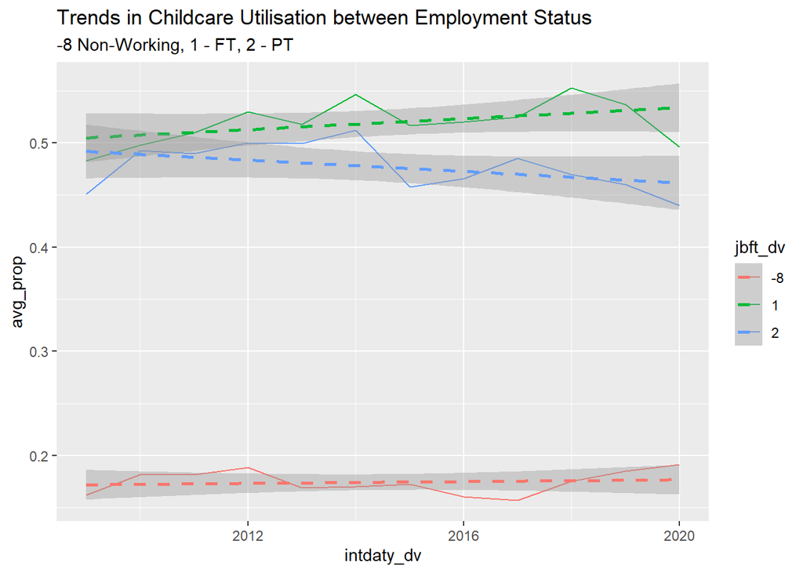

```r
usoc %>%
  filter(intdaty_dv > 0 & intdaty_dv < 2021) %>%
  filter(ccare == 1 | ccare == 2) %>%
  filter(jbft_dv == 1 | jbft_dv == 2 | jbft_dv == -8) %>%
  mutate(jbft_dv = as.factor(jbft_dv)) %>%
  group_by(intdaty_dv, jbft_dv) %>%
  mutate(prop = 1 - (mean(ccare) - 1), n = n_distinct(pidp)) %>%
  summarise(avg_prop = mean(prop)) %>%
  ggplot(aes(x = intdaty_dv, y = avg_prop, group = jbft_dv, color = jbft_dv)) + geom_line() +
  labs(title = "Levels of Childcare Utilisation between Employment Status", subtitle = "-8 Non-Working, 1 - FT, 2 - PT")

usoc %>%
  filter(intdaty_dv > 0 & intdaty_dv < 2021) %>%
  filter(ccare == 1 | ccare == 2) %>%
  filter(jbft_dv == 1 | jbft_dv == 2 | jbft_dv == -8) %>%
  mutate(jbft_dv = as.factor(jbft_dv)) %>%
  group_by(intdaty_dv, jbft_dv) %>%
  mutate(prop = 1 - (mean(ccare) - 1), n = n_distinct(pidp)) %>%
  summarise(avg_prop = mean(prop)) %>%
  ggplot(aes(x = intdaty_dv, y = avg_prop, group = jbft_dv, color = jbft_dv)) + geom_line() +
  stat_smooth(method = "lm", formula = y ~ x, se = TRUE, linetype = "dashed", aes(color = jbft_dv)) +
  labs(title = "Trends in Childcare Utilisation between Employment Status", subtitle = "-8 Non-Working, 1 - FT, 2 - PT")
```

From the above two charts we can see the evolution of childcare utilisation for the three categories over time. Non-working parents levels are flat over the period with minimal volatility. Standard errors for the trend are muted over the period. Full-time workers (green) exhibit a somewhat upward trend, although looking at the overall levels it doesn’t appear too pronounced and this is mirrored by a decline in part-time childcare utilisation over the period.

We can suggest from this that there is a slight time-related component to the series that should be investigated.

```r
usoc %>%
  filter(intdaty_dv > 0 & intdaty_dv < 2021 & sex_dv > 0) %>%
  filter(ccare == 1 | ccare == 2 | ccare == -8) %>%
  mutate(ccare = as.factor(ccare)) %>%
  group_by(ccare) %>%
  mutate(sex_prop = 1 - (mean(sex_dv) - 1)) %>%
  summarise(percent_male = mean(sex_prop) * 100, percent_female = 100 - percent_male)
```

```
## # A tibble: 3 × 3
##   ccare percent_male percent_female
##   <fct>        <dbl>          <dbl>
## 1 -8           52.1            47.9
## 2 1             1.79           98.2
## 3 2             3.25           96.8
```

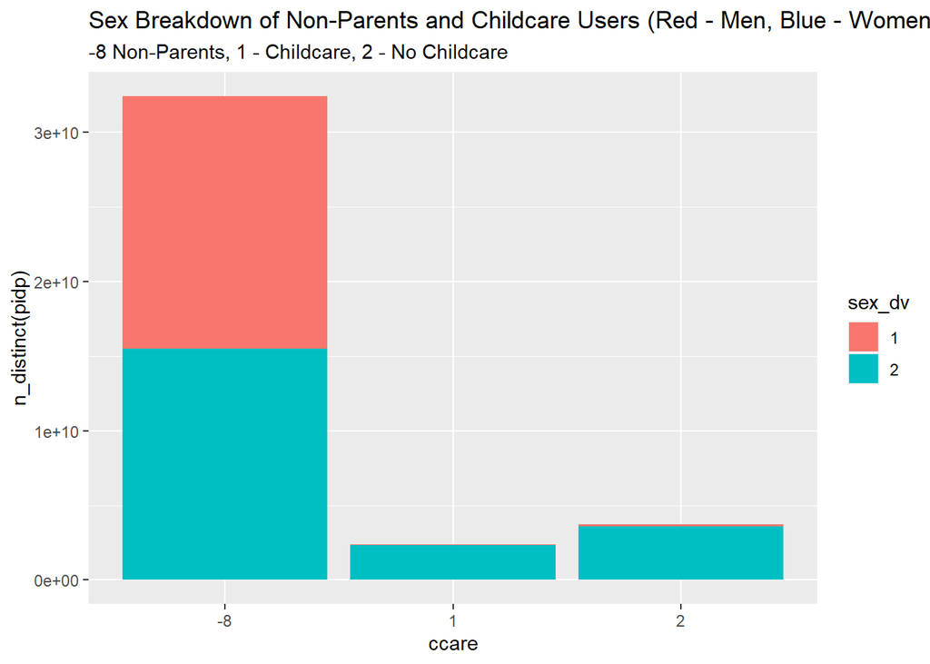

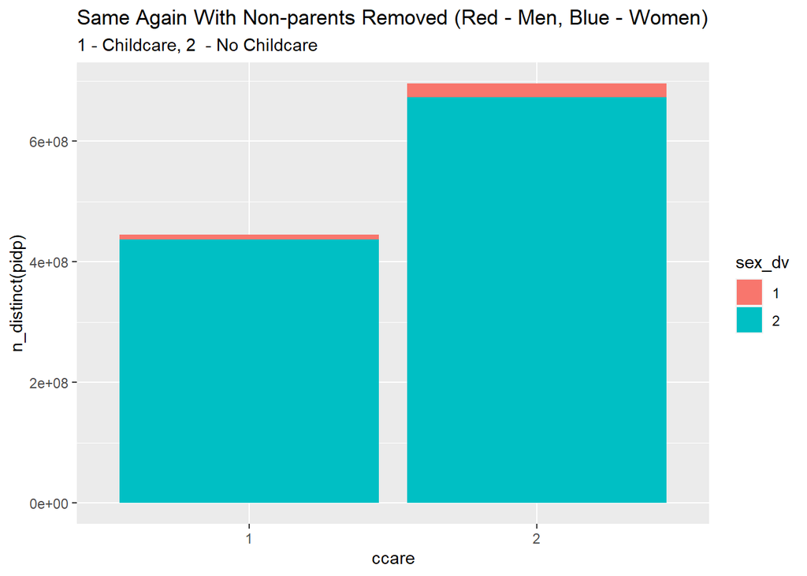

```r
usoc %>%
  filter(intdaty_dv > 0 & intdaty_dv < 2021 & sex_dv > 0) %>%
  filter(ccare == 1 | ccare == 2 | ccare == -8) %>%
  mutate(ccare = as.factor(ccare), sex_dv = as.factor(sex_dv)) %>%
  group_by(ccare) %>%
  ggplot(aes(x = ccare, y = n_distinct(pidp), fill = sex_dv)) + geom_col() +
  labs(title = "Sex Breakdown of Non-Parents and Childcare Users (Red - Men, Blue - Women)", subtitle = "-8 Non-Parents, 1 - Childcare, 2 - No Childcare")

usoc %>%
  filter(intdaty_dv > 0 & intdaty_dv < 2021 & sex_dv > 0) %>%
  filter(ccare == 1 | ccare == 2) %>%
  mutate(ccare = as.factor(ccare), sex_dv = as.factor(sex_dv)) %>%
  group_by(ccare) %>%
  ggplot(aes(x = ccare, y = n_distinct(pidp), fill = sex_dv)) + geom_col() +
  labs(title = "Same Again With Non-parents Removed (Red - Men, Blue - Women)", subtitle = "1 - Childcare, 2  - No Childcare")
```

Childcare by job status.

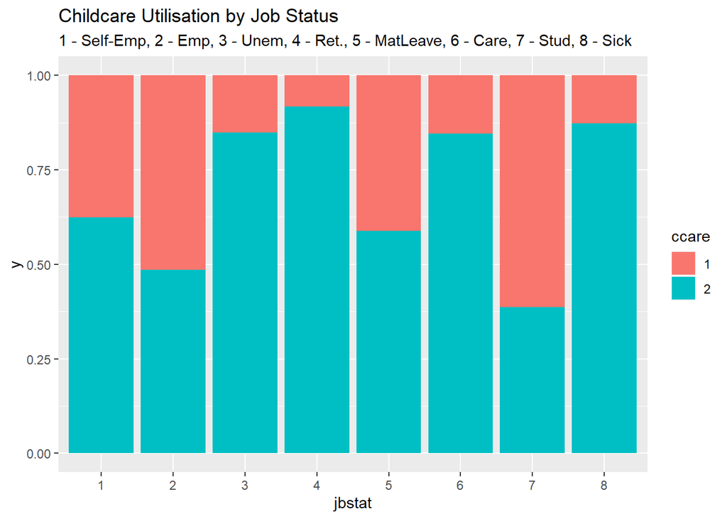

```r
usoc %>%
  filter(intdaty_dv > 0 & intdaty_dv < 2021 & sex_dv > 0) %>%
  filter(jbstat > 0 & jbstat < 9) %>%
  filter(ccare == 1 | ccare == 2) %>%
  mutate(jbstat = as.factor(jbstat), ccare = as.factor(ccare)) %>%
  group_by(jbstat) %>%
  ggplot(aes(x = jbstat, y = 100, fill = ccare)) + geom_col(position = "fill") +
  labs(title = "Childcare Utilisation by Job Status", subtitle = "1 - Self-Emp, 2 - Emp, 3 - Unem, 4 - Ret., 5 - MatLeave, 6 - Care, 7 - Stud, 8 - Sick")
```

## Childcare Utilisation Rates by Personal Characteristics

NOTE: Rebuild USOC with income indicators. Highest qualification as imperfect proxy for income level.

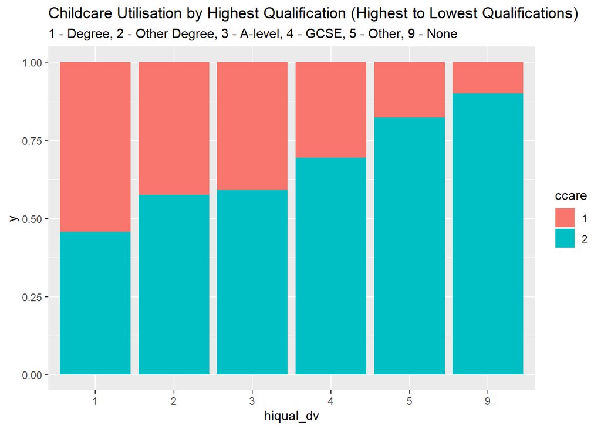

```r
usoc %>%
  filter(intdaty_dv > 0 & intdaty_dv < 2021 & sex_dv > 0 & hiqual_dv > 0) %>%
  filter(ccare == 1 | ccare == 2) %>%
  mutate(hiqual_dv = as.factor(hiqual_dv), ccare = as.factor(ccare)) %>%
  group_by(hiqual_dv) %>%
  ggplot(aes(x = hiqual_dv, y = 100, fill = ccare)) + geom_col(position = "fill") +
  labs(title = "Childcare Utilisation by Highest Qualification (Highest to Lowest Qualifications)", subtitle = "1 - Degree, 2 - Other Degree, 3 - A-level, 4 - GCSE, 5 - Other, 9 - None")
```

Same as above but with marital status

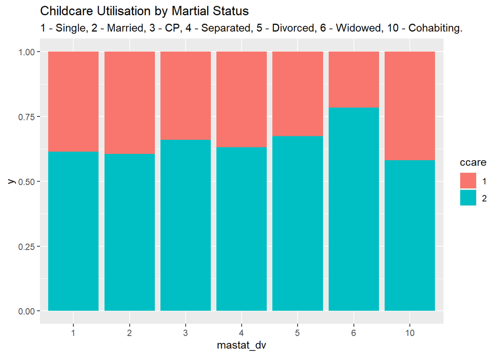

```r
usoc %>%
  filter(intdaty_dv > 0 & intdaty_dv < 2021 & sex_dv > 0) %>%
  filter(mastat_dv > 0 & mastat_dv < 7 | mastat_dv == 10) %>%
  filter(ccare == 1 | ccare == 2) %>%
  mutate(mastat_dv = as.factor(mastat_dv), ccare = as.factor(ccare)) %>%
  group_by(mastat_dv) %>%
  ggplot(aes(x = mastat_dv, y = 100, fill = ccare)) + geom_col(position = "fill") +
  labs(title = "Childcare Utilisation by Martial Status", subtitle = "1 - Single, 2 - Married, 3 - CP, 4 - Separated, 5 - Divorced, 6 - Widowed, 10 - Cohabiting.")
```